# Final Homework

This homework is to wrap up our last few units with some hands-on practice. It focuses on breadth rather than depth. They are very strongly based on exercises from the textbook. Submit a well-formatted and reproducible R Markdown document that shows the process and clearly specifies the answer.

This homework should be completed individually, but you are heartily invited to ask questions on Piazza.

A template for this assignment is found in the `hwFinal` folder of your portfolio repo.

## Supervised Learning

(*MDSR2e Exercise 11.4*) Build a decision tree classifier for the `type` of each storm in `nasaweather::storms` based on its `wind` speed and `pressure`. Report its accuracy.

**Note**: there is also a `storms` data frame in `dplyr`. Use the one in `nasaweather`.

```r
storms <- nasaweather::storms %>% mutate(type = as_factor(type))
head(storms)
```

```
## # A tibble: 6 × 11
##   name     year month   day  hour   lat  long pressure  wind type        seasday
##   <chr>   <int> <int> <int> <int> <dbl> <dbl>    <int> <int> <fct>         <int>
## 1 Allison  1995     6     3     0  17.4 -84.3     1005    30 Tropical D…       3
## 2 Allison  1995     6     3     6  18.3 -84.9     1004    30 Tropical D…       3
## 3 Allison  1995     6     3    12  19.3 -85.7     1003    35 Tropical S…       3
## 4 Allison  1995     6     3    18  20.6 -85.8     1001    40 Tropical S…       3
## 5 Allison  1995     6     4     0  22   -86        997    50 Tropical S…       4
## 6 Allison  1995     6     4     6  23.3 -86.3      995    60 Tropical S…       4
```

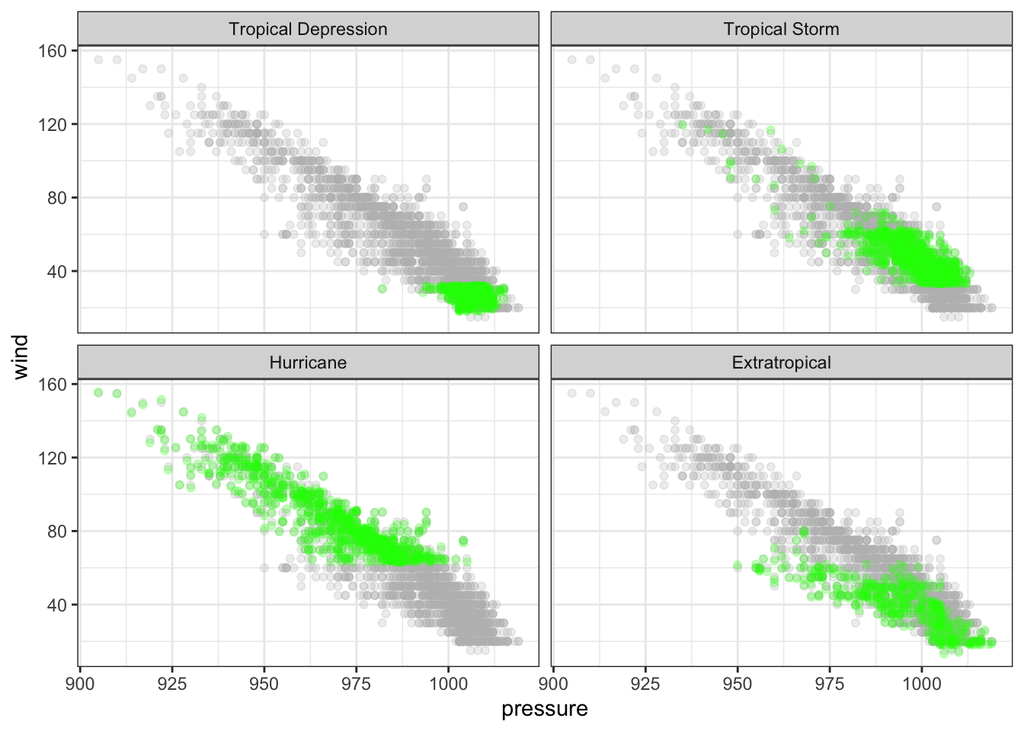

```r
ggplot(data = storms, aes(x = pressure, y = wind)) +
  geom_point(data = storms %>% select(-type), alpha = .25, color = "grey") +
  geom_point(alpha = .25, position = position_jitter(.1), color = "green") +
  facet_wrap(vars(type))
```

## Clustering

(*MDSR Exercise 12.1*) Consider the 4,000 biggest cities in the world, given by:

```r
big_cities <- mdsr::world_cities %>%
  arrange(desc(population)) %>%
  slice_head(n = 4000)
```

Construct a *k*-means clustering of the `latitude` and `longitude` of these cities. Describe (qualitatively) the results of clustering with *k*=2.

## Databases

(*MDSR Exercise 15.9c*) Which baseball players have hit 500 home runs (`HR`) OR 3000 hits (`H`) but have not (yet?) been inducted into the Baseball Hall of Fame?

Use the `Lahman` package.

```r
library(Lahman)
```

Consider:

- the `inducted` column of `HallOfFame`
- the `HR` and `H` columns of `Batting` (note that there are *many rows for each `playerID`*)
- the `nameFirst` and `nameLast` columns of `People`

## Text Data

1. (*MDSR Exercise 19.1a*) How many speaking lines are there in Macbeth? Speaking lines are identified by a line that starts with two spaces, then a string of capital letters (possibly including spaces) indicating the character’s name, followed by a period.
2. (*MDSR Exercise 19.4a*) Find the 10 most popular boys’ names in 2017 that end in a vowel. Use the `babynames::babynames` table. (Hint: `str_detect`.)